# Lab 9 Solution

Name

Date

We will analyze data from a sleep study in which several variables related to sleeping habits, cognitive ability, alcohol use, and mental health were recorded for a random sample of students. The source of the `SleepStudy` data is “Onyper, S., Thatcher, P., Gilbert, J., and Gradess, S., Class Start Times, Sleep and Academic Performance in College: A Path Analysis, *Chronobiology International*, April 2002; 29(3): 318-335.”

```r
SleepStudy <- read.table("SleepStudy.csv", header=TRUE, quote="\"")
```

We will begin by taking a look at the data before we perform any analysis.

```r
dim(SleepStudy)
```

```
## [1] 253  23
```

```r
library(Hmisc)
describe(SleepStudy)
```

```
## SleepStudy
##
##  23  Variables      253  Observations
## --------------------------------------------------------------------------------
## Gender
##        n  missing distinct     Info      Sum     Mean      Gmd
##      253        0        2    0.722      102   0.4032   0.4832
##
## --------------------------------------------------------------------------------
## ClassYear
##        n  missing distinct     Info     Mean      Gmd
##      253        0        4     0.92    2.478    1.149
##
## Value          1     2     3     4
## Frequency     47    95    54    57
## Proportion 0.186 0.375 0.213 0.225
## --------------------------------------------------------------------------------
## LarkOwl
##        n  missing distinct
##      253        0        3
##
## Value         Lark Neither     Owl
## Frequency       41     163      49
## Proportion   0.162   0.644   0.194
## --------------------------------------------------------------------------------
## NumEarlyClass
##        n  missing distinct     Info     Mean      Gmd
##      253        0        6    0.917    1.735    1.675
##
## lowest : 0 1 2 3 4, highest: 1 2 3 4 5
##
## Value          0     1     2     3     4     5
## Frequency     85    14    88    35    11    20
## Proportion 0.336 0.055 0.348 0.138 0.043 0.079
## --------------------------------------------------------------------------------
## EarlyClass
##        n  missing distinct     Info      Sum     Mean      Gmd
##      253        0        2    0.669      168    0.664    0.448
##
## --------------------------------------------------------------------------------
```

[output cut: 150 more lines]

```
## lowest :  4.00  4.38  4.84  5.00  5.25, highest: 10.50 10.75 11.00 11.50 12.75
## --------------------------------------------------------------------------------
## AverageSleep
##        n  missing distinct     Info     Mean      Gmd      .05      .10
##      253        0      160        1    7.966    1.078    6.170    6.592
##      .25      .50      .75      .90      .95
##    7.430    8.000    8.590    9.068    9.462
##
## lowest :  4.95  5.02  5.64  5.75  5.78, highest:  9.87  9.96 10.00 10.45 10.62
## --------------------------------------------------------------------------------
## AllNighter
##        n  missing distinct     Info      Sum     Mean      Gmd
##      253        0        2    0.349       34   0.1344   0.2336
##
## --------------------------------------------------------------------------------
```

## Investigation of the Variables in `SleepStudy`

### `ClassYear` and `NumEarlyClass`

`ClassYear` is the year the student is in college with level 1 corresponding to the first year through level 4 corresponding to seniors.

`NumEarlyClass` is the number of early classes the student has in a week.

```r
table(SleepStudy$ClassYear)
```

```
##
##  1  2  3  4
## 47 95 54 57
```

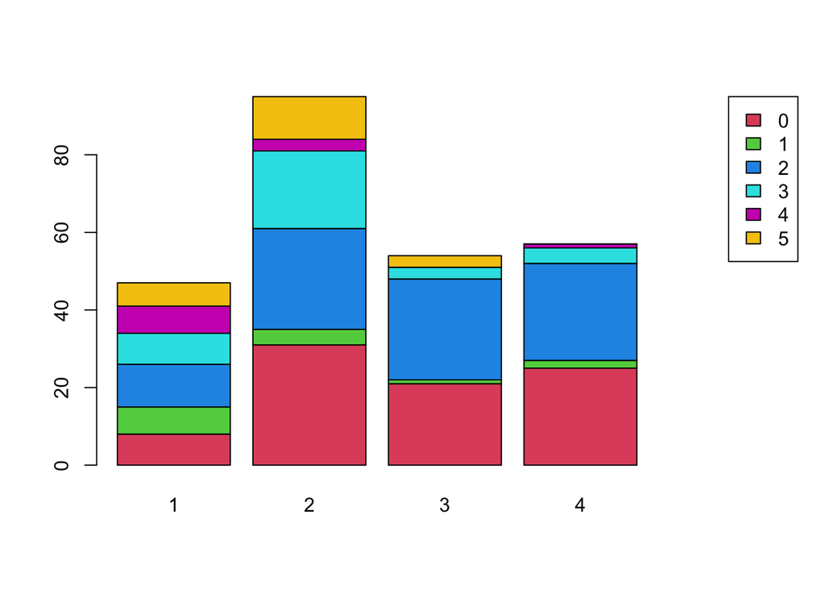

```r
EarlyByClass <- table(SleepStudy$NumEarlyClass, SleepStudy$ClassYear)
PropEbyC <- prop.table(EarlyByClass, margin=2)
par(mar = c(5.1, 4.1, 4.1, 7.1), xpd = TRUE)
barplot(EarlyByClass, col = 2:7, width = 2)
legend("topright", inset = c(-0.25, 0), fill = 2:7,
       legend = rownames(EarlyByClass))
```

It appears that the further a student is in school, the less early classes he/she is willing to take.

### `Drinks` and `AlcoholUse`

`Drinks` is the number of alcoholic drinks the student has per week.

`AlcoholUse` is a categorical variable where the student indicated his/her level of alcohol use. The levels of `AlcoholUse` are `Abstain`, `Light`, `Moderate`, and `Heavy`.

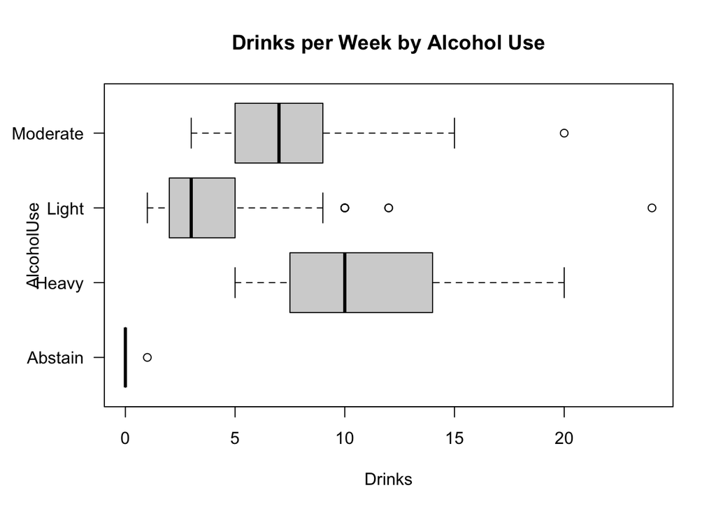

```r
par(mar = c(5, 5, 4, 2) + 0.1)
boxplot(Drinks~AlcoholUse, data = SleepStudy, horizontal = TRUE, las = 1,
        main = 'Drinks per Week by Alcohol Use')
```

Some notable observations from this plot are

1. A student who indicated that he/she abstains from alcohol has a drink a week.
2. One of the students who indicated his/her alcohol use was light has more drinks per week than all of the students who characterized their drinking as heavy.
3. One of the students who indicated his/her alcohol use was moderate has as many drinks per week as all of the students who characterized their drinking as heavy.

## Examining the Differences in Sleep Patterns on Weekdays Versus Weekend Days

`WeekdaySleep` is the number of hours the student sleeps on average per night on the weekdays.

`WeekendSleep` is the number of hours the student sleeps on average per night on the weekends.

```r
SleepStudy$Differences = SleepStudy$WeekendSleep - SleepStudy$WeekdaySleep
smean=mean(SleepStudy$Differences)
n=dim(SleepStudy)[1]
SE=sqrt((var(SleepStudy$Differences)/n))
crit=qnorm(.975)
Upper = smean + SE*crit
Lower = smean - SE*crit
Lower
```

```
## [1] 0.1440282
```

```r
Upper
```

```
## [1] 0.5584224
```

We are 95% confident that the mean difference of the average number of hours slept per night on the weekdays versus the weekends is in the interval (0.144,0.5584).

The upper endpoint of this confidence interval is about 0.56. This indicates with 95% confidence on average students at most sleep only a little more than a half hour more per day on the weekend versus the weekdays.

```r
t.test(SleepStudy$Differences)
```

```
##
##  One Sample t-test
##
## data:  SleepStudy$Differences
## t = 3.3224, df = 252, p-value = 0.001025
## alternative hypothesis: true mean is not equal to 0
## 95 percent confidence interval:
##  0.1430283 0.5594223
## sample estimates:
## mean of x
## 0.3512253
```

## Comparing the Mean GPA for This College to the National Average

`GPA` is the student’s grade point average.

Here we will test whether the mean GPA for the college these students were sampled from is equal to the national average of 3.0.

The null hypothesis of this test is $H_0: \mu = 3$. The alternative hypothesis is $H_a: \mu \neq 3$.

The p-value of this test is $2P(\bar X_{253} > |\bar x_{253}|$ given $H_0 \text { is true})$

```r
SE = sd(SleepStudy$GPA) / sqrt(n)
2*(1-pnorm(abs(mean(SleepStudy$GPA)), 3, SE))
```

```
## [1] 0
```

This p-value is close to 0. So, since $0 < 0.01$, we reject the null hypothesis that the mean GPA for the college from which this sample was taken is equal to the mean GPA for all U.S. colleges.

```r
result = t.test(SleepStudy$GPA, mu = 3, conf.level = 0.99)
result$p.value
```

```
## [1] 8.964262e-19
```